# DA 101 Lec 15

Your Name

23 October, 2019

## Lin Reg Group Practice – House Sales

```r
houseSales <- read_csv("House-Sales.csv")

houseSales %>% head
```

| id | date | price | bedrooms | bathrooms | sqft_living | sqft_lot | improvements | floors | waterfront | view | hoa | condition | grade | sqft_above | sqft_basement | yr_built | yr_renovated | zipcode | lat | long | sqft_living15 | sqft_lot15 |
| --- | --- | --- | --- | --- | --- | --- | --- | --- | --- | --- | --- | --- | --- | --- | --- | --- | --- | --- | --- | --- | --- | --- |
| 7129300520 | 2014-10-13 | 221900 | 3 | 1.00 | 1180 | 5650 | 5 | 1 | 0 | 0 | No | Low | Low | 1180 | 0 | 1955 | 0 | 98178 | 47.5112 | -122.257 | 1340 | 5650 |
| 6414100192 | 2014-12-09 | 538000 | 3 | 2.25 | 2570 | 7242 | 8 | 2 | 0 | 0 | No | Low | Low | 2170 | 400 | 1951 | 1991 | 98125 | 47.7210 | -122.319 | 1690 | 7639 |
| 5631500400 | 2015-02-25 | 180000 | 2 | 1.00 | 770 | 10000 | 4 | 1 | 0 | 0 | No | Low | Low | 770 | 0 | 1933 | 0 | 98028 | 47.7379 | -122.233 | 2720 | 8062 |
| 2487200875 | 2014-12-09 | 604000 | 4 | 3.00 | 1960 | 5000 | 3 | 1 | 0 | 0 | No | High | Low | 1050 | 910 | 1965 | 0 | 98136 | 47.5208 | -122.393 | 1360 | 5000 |
| 1954400510 | 2015-02-18 | 510000 | 3 | 2.00 | 1680 | 8080 | 5 | 1 | 0 | 0 | Yes | Low | Medium | 1680 | 0 | 1987 | 0 | 98074 | 47.6168 | -122.045 | 1800 | 7503 |
| 7237550310 | 2014-05-12 | 1230000 | 4 | 4.50 | 5420 | 101930 | 5 | 1 | 0 | 0 | No | Low | High | 3890 | 1530 | 2001 | 0 | 98053 | 47.6561 | -122.005 | 4760 | 101930 |

```r
houseSales %>% nrow
```

```
## [1] 21613
```

The game: I’ll give each group a variable. You guys will make a linear model to predict PRICE based upon this model. Based upon YOUR model:

- interpret the coefficients (slope, intercept)
- interpret r^2
- interpret the residual plot

Group 1: Bedrooms

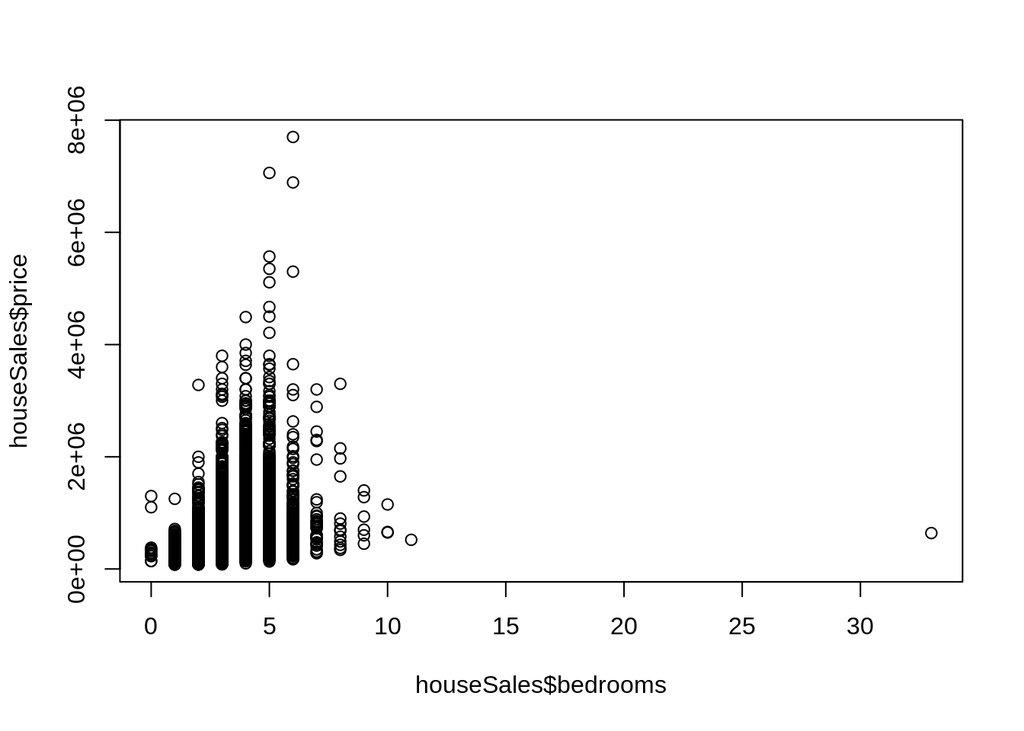

```r
plot(houseSales$bedrooms, houseSales$price)
```

```r
priceMod <- lm(houseSales$price~houseSales$bedrooms)
summary(priceMod)
```

```
##
## Call:
## lm(formula = houseSales$price ~ houseSales$bedrooms)
##
## Residuals:
##      Min       1Q   Median       3Q      Max
## -3508706  -203228   -66728   104982  6839614
##
## Coefficients:
##                     Estimate Std. Error t value Pr(>|t|)
## (Intercept)           129649       8938   14.51   <2e-16 ***
## houseSales$bedrooms   121790       2556   47.65   <2e-16 ***
## ---
## Signif. codes:  0 '***' 0.001 '**' 0.01 '*' 0.05 '.' 0.1 ' ' 1
##
## Residual standard error: 349500 on 21611 degrees of freedom
## Multiple R-squared:  0.09507,    Adjusted R-squared:  0.09503
## F-statistic:  2270 on 1 and 21611 DF,  p-value: < 2.2e-16
```

Interpret slope: If the number of bed increases by 1, we expect the price of the house to increase by 121,790.

R^2: About 9.5% of the variation in price is due to the linear rel with beds. Of course, bedrooms aren’t the only factor. But, of all the variation in price, bedrooms account for 9.5%.

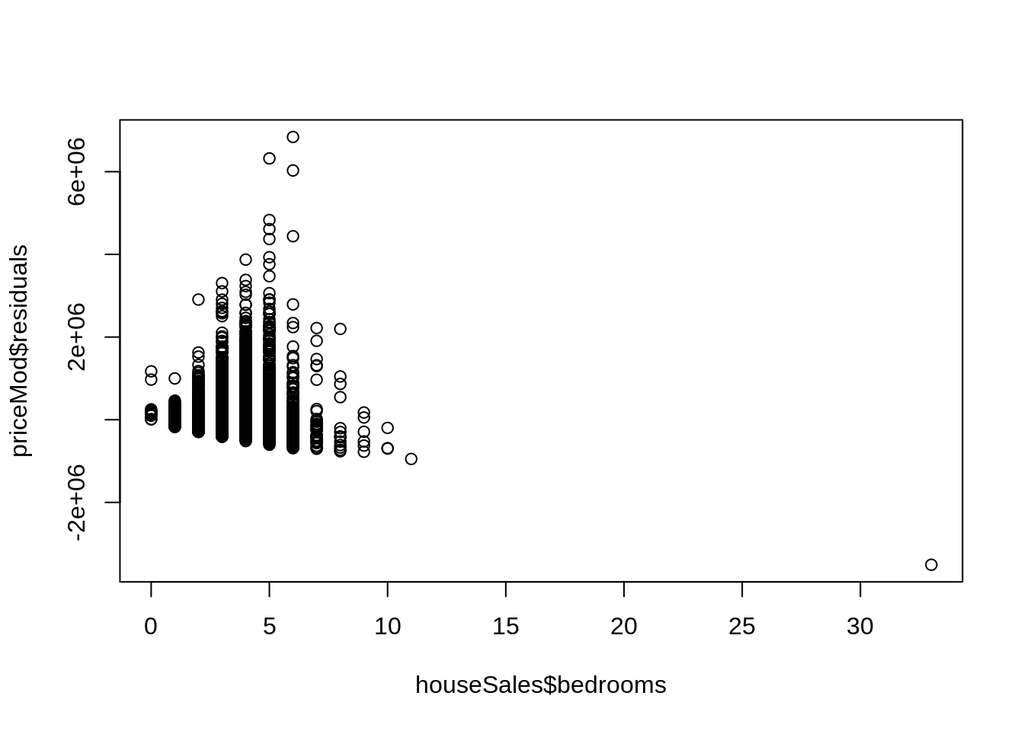

```r
plot(houseSales$bedrooms, priceMod$residuals)
```

These resids are not homoskedastic. Low variance at the ends, and high variance in the middle. Another way: hereroskedastic. Bad.

Group 2: Bathrooms

Group 3: sqft_living

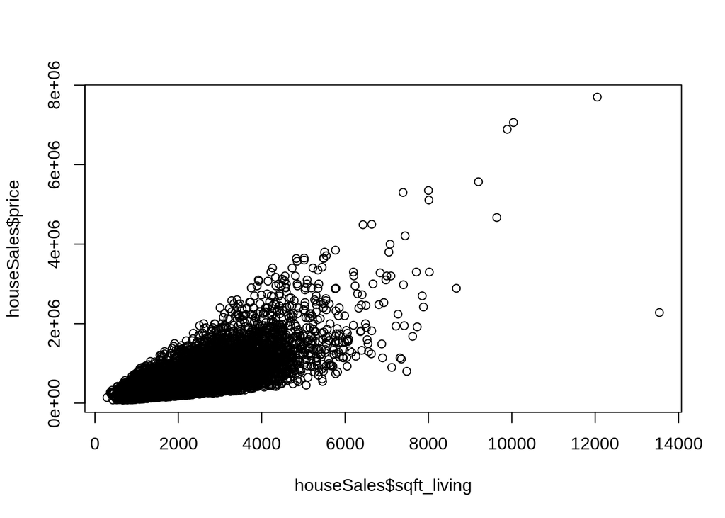

```r
plot(houseSales$sqft_living, houseSales$price)
```

```r
priceMod <- lm(houseSales$price~houseSales$sqft_living)
summary(priceMod)
```

```
##
## Call:
## lm(formula = houseSales$price ~ houseSales$sqft_living)
##
## Residuals:
##      Min       1Q   Median       3Q      Max
## -1478255  -147564   -24169   106283  4360147
##
## Coefficients:
##                          Estimate Std. Error t value Pr(>|t|)
## (Intercept)            -43867.602   4405.455  -9.958   <2e-16 ***
## houseSales$sqft_living    280.807      1.938 144.924   <2e-16 ***
## ---
## Signif. codes:  0 '***' 0.001 '**' 0.01 '*' 0.05 '.' 0.1 ' ' 1
##
## Residual standard error: 261600 on 21611 degrees of freedom
## Multiple R-squared:  0.4929, Adjusted R-squared:  0.4928
## F-statistic: 2.1e+04 on 1 and 21611 DF,  p-value: < 2.2e-16
```

Slope in general: if x increase by 1 unit, we expect y to change by the slope.

Here: x = sqft_living, y = price. If a house’s living sqft increases by 1 square ft, we expect the price to increase by $280.807.

R^2: About 49% of the variation in price is due to effect of the relationship with sqft. We know sqft can’t be the only thing, but it’s a big one! It accounts for about half of the price. makes sense! Bigger houses tend to be more expensive.

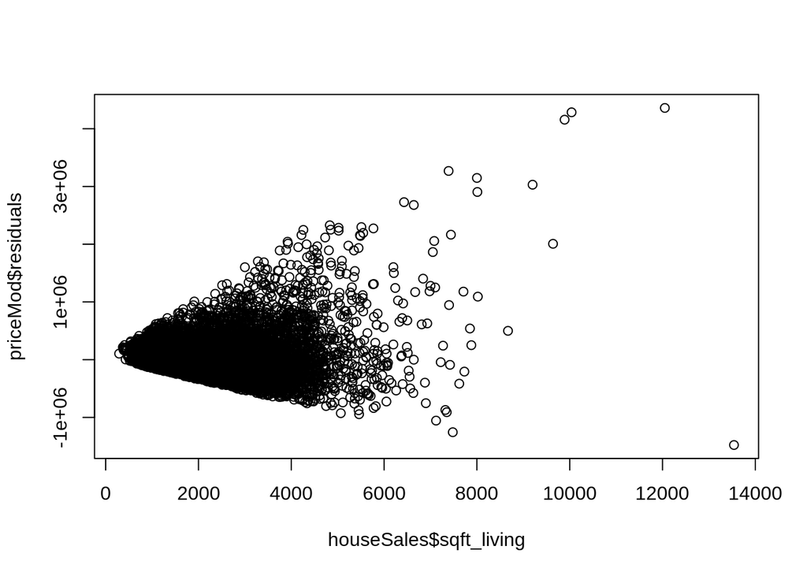

```r
plot(houseSales$sqft_living, priceMod$residuals)
```

This is a textbook example of non-homoskedasticity. We clearly see variance increasing as size increases. Takeaways:

- We’re seeing a pattern in the residuals, suggesting the linear model isn’t the best or most appropriate.
- For small houses, the model does a good job (small residuals). For very large houses, our model has lots of error. Makes sense – very large houses are unusual! Don’t fit the pattern!

## Next Topic: Multilinear models

What if we want to consider more than one variable? Not just sqft, not just bathrooms, not just bedrooms, etc. How can we see the effect of all of them?

```r
#predict price  (y = price)
multiModel <- lm(price~bedrooms+bathrooms+sqft_living+improvements+yr_built, data=houseSales)

summary(multiModel)
```

```
##
## Call:
## lm(formula = price ~ bedrooms + bathrooms + sqft_living + improvements +
##     yr_built, data = houseSales)
##
## Residuals:
##      Min       1Q   Median       3Q      Max
## -1852759  -131836   -17220    99826  3950839
##
## Coefficients:
##                Estimate Std. Error t value Pr(>|t|)
## (Intercept)   6.025e+06  1.301e+05  46.324   <2e-16 ***
## bedrooms     -6.966e+04  2.245e+03 -31.032   <2e-16 ***
## bathrooms     8.296e+04  3.732e+03  22.231   <2e-16 ***
## sqft_living   3.002e+02  2.956e+00 101.571   <2e-16 ***
## improvements  7.585e+02  5.862e+02   1.294    0.196
## yr_built     -3.071e+03  6.699e+01 -45.852   <2e-16 ***
## ---
## Signif. codes:  0 '***' 0.001 '**' 0.01 '*' 0.05 '.' 0.1 ' ' 1
##
## Residual standard error: 246300 on 21607 degrees of freedom
## Multiple R-squared:  0.5507, Adjusted R-squared:  0.5506
## F-statistic:  5296 on 5 and 21607 DF,  p-value: < 2.2e-16
```

Cool! R^2 is bigger! Did more variables help? To be continued…